# Unsupervised Learning: Trade & Ahead

## Problem Statement

### Context

The stock market has consistently proven to be a good place to invest in and save for the future. There are a lot of compelling reasons to invest in stocks. It can help in fighting inflation, create wealth, and also provides some tax benefits. Good steady returns on investments over a long period of time can also grow a lot more than seems possible. Also, thanks to the power of compound interest, the earlier one starts investing, the larger the corpus one can have for retirement. Overall, investing in stocks can help meet life's financial aspirations.

It is important to maintain a diversified portfolio when investing in stocks in order to maximise earnings under any market condition. Having a diversified portfolio tends to yield higher returns and face lower risk by tempering potential losses when the market is down. It is often easy to get lost in a sea of financial metrics to analyze while determining the worth of a stock, and doing the same for a multitude of stocks to identify the right picks for an individual can be a tedious task. By doing a cluster analysis, one can identify stocks that exhibit similar characteristics and ones which exhibit minimum correlation. This will help investors better analyze stocks across different market segments and help protect against risks that could make the portfolio vulnerable to losses.

### Objective

Trade&Ahead is a financial consultancy firm who provide their customers with personalized investment strategies. They have hired you as a Data Scientist and provided you with data comprising stock price and some financial indicators for a few companies listed under the New York Stock Exchange. They have assigned you the tasks of analyzing the data, grouping the stocks based on the attributes provided, and sharing insights about the characteristics of each group.

### Data Dictionary

- Ticker Symbol: An abbreviation used to uniquely identify publicly traded shares of a particular stock on a particular stock market
- Company: Name of the company
- GICS Sector: The specific economic sector assigned to a company by the Global Industry Classification Standard (GICS) that best defines its business operations
- GICS Sub Industry: The specific sub-industry group assigned to a company by the Global Industry Classification Standard (GICS) that best defines its business operations
- Current Price: Current stock price in dollars
- Price Change: Percentage change in the stock price in 13 weeks
- Volatility: Standard deviation of the stock price over the past 13 weeks
- ROE: A measure of financial performance calculated by dividing net income by shareholders' equity (shareholders' equity is equal to a company's assets minus its debt)
- Cash Ratio: The ratio of a company's total reserves of cash and cash equivalents to its total current liabilities
- Net Cash Flow: The difference between a company's cash inflows and outflows (in dollars)
- Net Income: Revenues minus expenses, interest, and taxes (in dollars)
- Earnings Per Share: Company's net profit divided by the number of common shares it has outstanding (in dollars)
- Estimated Shares Outstanding: Company's stock currently held by all its shareholders
- P/E Ratio: Ratio of the company's current stock price to the earnings per share
- P/B Ratio: Ratio of the company's stock price per share by its book value per share (book value of a company is the net difference between that company's total assets and total liabilities)

## Importing necessary libraries and data

```python
# Installing the libraries with the specified version.
# uncomment and run the following line if Google Colab is being used
# !pip install scikit-learn==1.6.1 seaborn==0.13.2 matplotlib==3.10.0 numpy==2.0.2 pandas==2.2.2 yellowbrick==1.5 -q --user
```

```python
# Installing the libraries with the specified version.
# uncomment and run the following lines if Jupyter Notebook is being used
# !pip install scikit-learn==1.2.2 seaborn==0.13.1 matplotlib==3.7.1 numpy==1.25.2 pandas==1.5.2 yellowbrick==1.5 -q --user
# !pip install --upgrade -q jinja2
```

**Note**: *After running the above cell, kindly restart the notebook kernel and run all cells sequentially from the start again.*

```python
from google.colab import drive
drive.mount('/content/drive')
```

```python
import pandas as pd
import numpy as np

import matplotlib.pylab as plt
%matplotlib inline

import seaborn as sns
from sklearn.model_selection  import train_test_split
from sklearn.cluster import KMeans

from scipy.stats import zscore

# to scale the data using z-score
from sklearn.preprocessing import StandardScaler

# to compute distances
from scipy.spatial.distance import cdist

# to perform k-means clustering and compute silhouette scores
from sklearn.cluster import KMeans
from sklearn.metrics import silhouette_score

# to visualize the elbow curve and silhouette scores
from yellowbrick.cluster import KElbowVisualizer, SilhouetteVisualizer

# to perform PCA
from sklearn.decomposition import PCA

# to compute distances
from scipy.spatial.distance import pdist

# to perform hierarchical clustering, compute cophenetic correlation, and create dendrograms
from sklearn.cluster import AgglomerativeClustering
from scipy.cluster.hierarchy import dendrogram, linkage, cophenet

#import sklearn.metrics

df = pd.read_csv("/content/drive/MyDrive/Python Course/stock_data.csv")
```

## Data Overview

- Observations
- Sanity checks

```python
#Check first 5 rows of dataset
df.head()
```

|  | Ticker Symbol | Security | GICS Sector | GICS Sub Industry | Current Price | Price Change | Volatility | ROE | Cash Ratio | Net Cash Flow | Net Income | Earnings Per Share | Estimated Shares Outstanding | P/E Ratio | P/B Ratio |
| --- | --- | --- | --- | --- | --- | --- | --- | --- | --- | --- | --- | --- | --- | --- | --- |
| 0 | AAL | American Airlines Group | Industrials | Airlines | 42.349998 | 9.999995 | 1.687151 | 135 | 51 | -604000000 | 7610000000 | 11.39 | 6.681299e+08 | 3.718174 | -8.784219 |
| 1 | ABBV | AbbVie | Health Care | Pharmaceuticals | 59.240002 | 8.339433 | 2.197887 | 130 | 77 | 51000000 | 5144000000 | 3.15 | 1.633016e+09 | 18.806350 | -8.750068 |
| 2 | ABT | Abbott Laboratories | Health Care | Health Care Equipment | 44.910000 | 11.301121 | 1.273646 | 21 | 67 | 938000000 | 4423000000 | 2.94 | 1.504422e+09 | 15.275510 | -0.394171 |
| 3 | ADBE | Adobe Systems Inc | Information Technology | Application Software | 93.940002 | 13.977195 | 1.357679 | 9 | 180 | -240840000 | 629551000 | 1.26 | 4.996437e+08 | 74.555557 | 4.199651 |
| 4 | ADI | Analog Devices, Inc. | Information Technology | Semiconductors | 55.320000 | -1.827858 | 1.701169 | 14 | 272 | 315120000 | 696878000 | 0.31 | 2.247994e+09 | 178.451613 | 1.059810 |

```python
#Check last 5 rows of dataset
df.tail()
```

|  | Ticker Symbol | Security | GICS Sector | GICS Sub Industry | Current Price | Price Change | Volatility | ROE | Cash Ratio | Net Cash Flow | Net Income | Earnings Per Share | Estimated Shares Outstanding | P/E Ratio | P/B Ratio |
| --- | --- | --- | --- | --- | --- | --- | --- | --- | --- | --- | --- | --- | --- | --- | --- |
| 335 | YHOO | Yahoo Inc. | Information Technology | Internet Software & Services | 33.259998 | 14.887727 | 1.845149 | 15 | 459 | -1032187000 | -4359082000 | -4.64 | 939457327.6 | 28.976191 | 6.261775 |
| 336 | YUM | Yum! Brands Inc | Consumer Discretionary | Restaurants | 52.516175 | -8.698917 | 1.478877 | 142 | 27 | 159000000 | 1293000000 | 2.97 | 435353535.4 | 17.682214 | -3.838260 |
| 337 | ZBH | Zimmer Biomet Holdings | Health Care | Health Care Equipment | 102.589996 | 9.347683 | 1.404206 | 1 | 100 | 376000000 | 147000000 | 0.78 | 188461538.5 | 131.525636 | -23.884449 |
| 338 | ZION | Zions Bancorp | Financials | Regional Banks | 27.299999 | -1.158588 | 1.468176 | 4 | 99 | -43623000 | 309471000 | 1.20 | 257892500.0 | 22.749999 | -0.063096 |
| 339 | ZTS | Zoetis | Health Care | Pharmaceuticals | 47.919998 | 16.678836 | 1.610285 | 32 | 65 | 272000000 | 339000000 | 0.68 | 498529411.8 | 70.470585 | 1.723068 |

```python
#Check shape of data
df.shape
```

```
(340, 15)
```

```python
#Check dataset types in dataset
df.info()
```

```
<class 'pandas.core.frame.DataFrame'>
RangeIndex: 340 entries, 0 to 339
Data columns (total 15 columns):
 #   Column                        Non-Null Count  Dtype
---  ------                        --------------  -----
 0   Ticker Symbol                 340 non-null    object
 1   Security                      340 non-null    object
 2   GICS Sector                   340 non-null    object
 3   GICS Sub Industry             340 non-null    object
 4   Current Price                 340 non-null    float64
 5   Price Change                  340 non-null    float64
 6   Volatility                    340 non-null    float64
 7   ROE                           340 non-null    int64
 8   Cash Ratio                    340 non-null    int64
 9   Net Cash Flow                 340 non-null    int64
 10  Net Income                    340 non-null    int64
 11  Earnings Per Share            340 non-null    float64
 12  Estimated Shares Outstanding  340 non-null    float64
 13  P/E Ratio                     340 non-null    float64
 14  P/B Ratio                     340 non-null    float64
dtypes: float64(7), int64(4), object(4)
memory usage: 40.0+ KB
```

```python
#Check high level statistics of data
df.describe().T
```

|  | count | mean | std | min | 25% | 50% | 75% | max |
| --- | --- | --- | --- | --- | --- | --- | --- | --- |
| Current Price | 340.0 | 8.086234e+01 | 9.805509e+01 | 4.500000e+00 | 3.855500e+01 | 5.970500e+01 | 9.288000e+01 | 1.274950e+03 |
| Price Change | 340.0 | 4.078194e+00 | 1.200634e+01 | -4.712969e+01 | -9.394838e-01 | 4.819505e+00 | 1.069549e+01 | 5.505168e+01 |
| Volatility | 340.0 | 1.525976e+00 | 5.917984e-01 | 7.331632e-01 | 1.134878e+00 | 1.385593e+00 | 1.695549e+00 | 4.580042e+00 |
| ROE | 340.0 | 3.959706e+01 | 9.654754e+01 | 1.000000e+00 | 9.750000e+00 | 1.500000e+01 | 2.700000e+01 | 9.170000e+02 |
| Cash Ratio | 340.0 | 7.002353e+01 | 9.042133e+01 | 0.000000e+00 | 1.800000e+01 | 4.700000e+01 | 9.900000e+01 | 9.580000e+02 |
| Net Cash Flow | 340.0 | 5.553762e+07 | 1.946365e+09 | -1.120800e+10 | -1.939065e+08 | 2.098000e+06 | 1.698108e+08 | 2.076400e+10 |
| Net Income | 340.0 | 1.494385e+09 | 3.940150e+09 | -2.352800e+10 | 3.523012e+08 | 7.073360e+08 | 1.899000e+09 | 2.444200e+10 |
| Earnings Per Share | 340.0 | 2.776662e+00 | 6.587779e+00 | -6.120000e+01 | 1.557500e+00 | 2.895000e+00 | 4.620000e+00 | 5.009000e+01 |
| Estimated Shares Outstanding | 340.0 | 5.770283e+08 | 8.458496e+08 | 2.767216e+07 | 1.588482e+08 | 3.096751e+08 | 5.731175e+08 | 6.159292e+09 |
| P/E Ratio | 340.0 | 3.261256e+01 | 4.434873e+01 | 2.935451e+00 | 1.504465e+01 | 2.081988e+01 | 3.176476e+01 | 5.280391e+02 |
| P/B Ratio | 340.0 | -1.718249e+00 | 1.396691e+01 | -7.611908e+01 | -4.352056e+00 | -1.067170e+00 | 3.917066e+00 | 1.290646e+02 |

```python
#Check for null data in dataset
df.isnull().sum()
```

|  | 0 |
| --- | --- |
| Ticker Symbol | 0 |
| Security | 0 |
| GICS Sector | 0 |
| GICS Sub Industry | 0 |
| Current Price | 0 |
| Price Change | 0 |
| Volatility | 0 |
| ROE | 0 |
| Cash Ratio | 0 |
| Net Cash Flow | 0 |
| Net Income | 0 |
| Earnings Per Share | 0 |
| Estimated Shares Outstanding | 0 |
| P/E Ratio | 0 |
| P/B Ratio | 0 |

**dtype:** int64

```python
#Check for duplicate rows in dataset
df.duplicated().sum()
```

```
np.int64(0)
```

No duplicate or N/A data found in dataset.

Dataset has object, float, and int data types.

Large discrepency in range of datastes. Standardization of the data will be needed for K-Means and hierarchical clustering.

## Exploratory Data Analysis (EDA)

- EDA is an important part of any project involving data.
- It is important to investigate and understand the data better before building a model with it.
- A few questions have been mentioned below which will help you approach the analysis in the right manner and generate insights from the data.
- A thorough analysis of the data, in addition to the questions mentioned below, should be done.

**Questions**:

1. What does the distribution of stock prices look like?
2. The stocks of which economic sector have seen the maximum price increase on average?
3. How are the different variables correlated with each other?
4. Cash ratio provides a measure of a company's ability to cover its short-term obligations using only cash and cash equivalents. How does the average cash ratio vary across economic sectors?
5. P/E ratios can help determine the relative value of a company's shares as they signify the amount of money an investor is willing to invest in a single share of a company per dollar of its earnings. How does the P/E ratio vary, on average, across economic sectors?

### **Univariate Analysis**

```python
#Function to plot all variables for univariate analysis in the dataset
def univar(datfr):
  print("Univariate Analysis")
  cols = datfr.columns

  for col in cols:
    col_dtype = datfr[col].dtype

    print(f"\n{col}")
    print('\n-------------------------------------------------------------------\n')

    if col_dtype == 'object':
      fig, ax = plt.subplots(figsize=(15, 15))
      sns.countplot(datfr[col], ax=ax)
      plt.xticks(rotation=90)
      plt.show()
    elif col_dtype == 'int64' or col_dtype == 'float64':
      sns.histplot(datfr[col])
      plt.show()
      sns.boxplot(datfr[col])
      plt.show()
      print(datfr[col].describe().T)

    print('\n-------------------------------------------------------------------\n')
```

```
Univariate Analysis

Ticker Symbol

-------------------------------------------------------------------
```

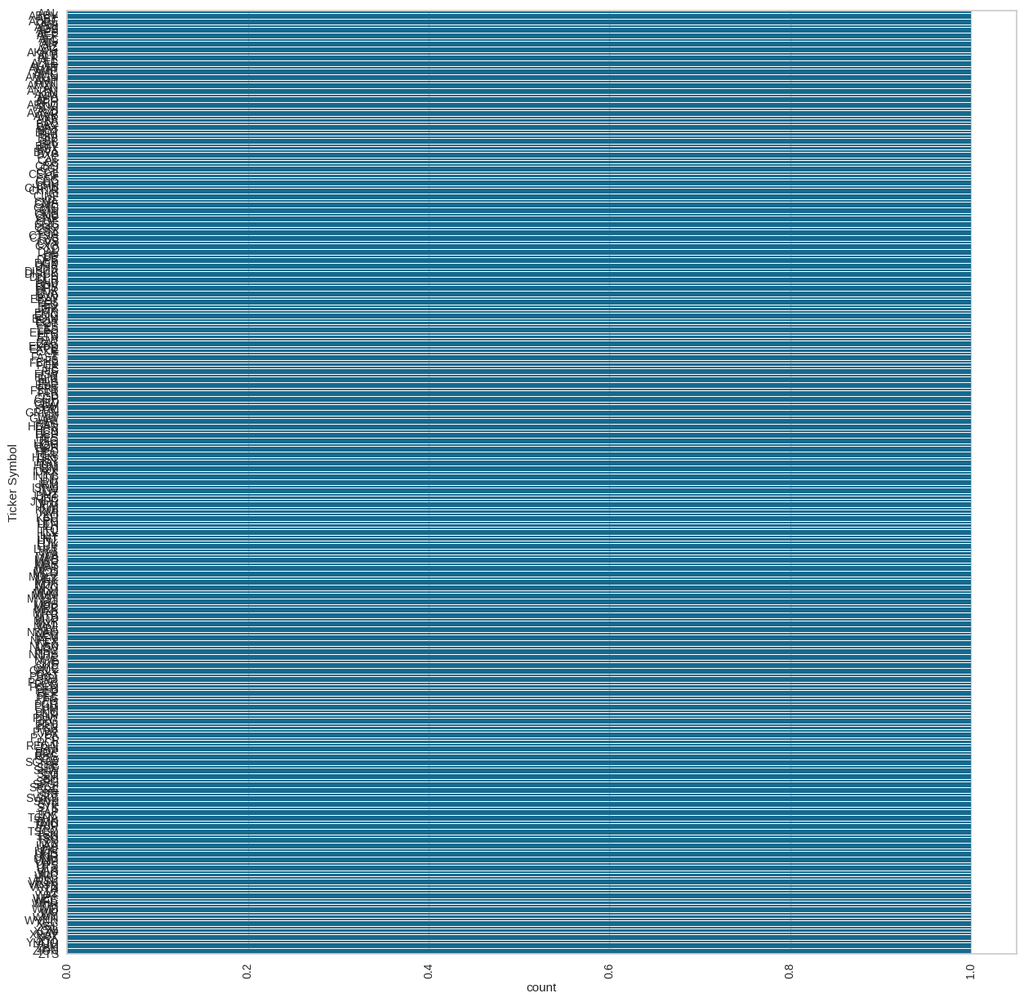

```
-------------------------------------------------------------------


Security

-------------------------------------------------------------------
```

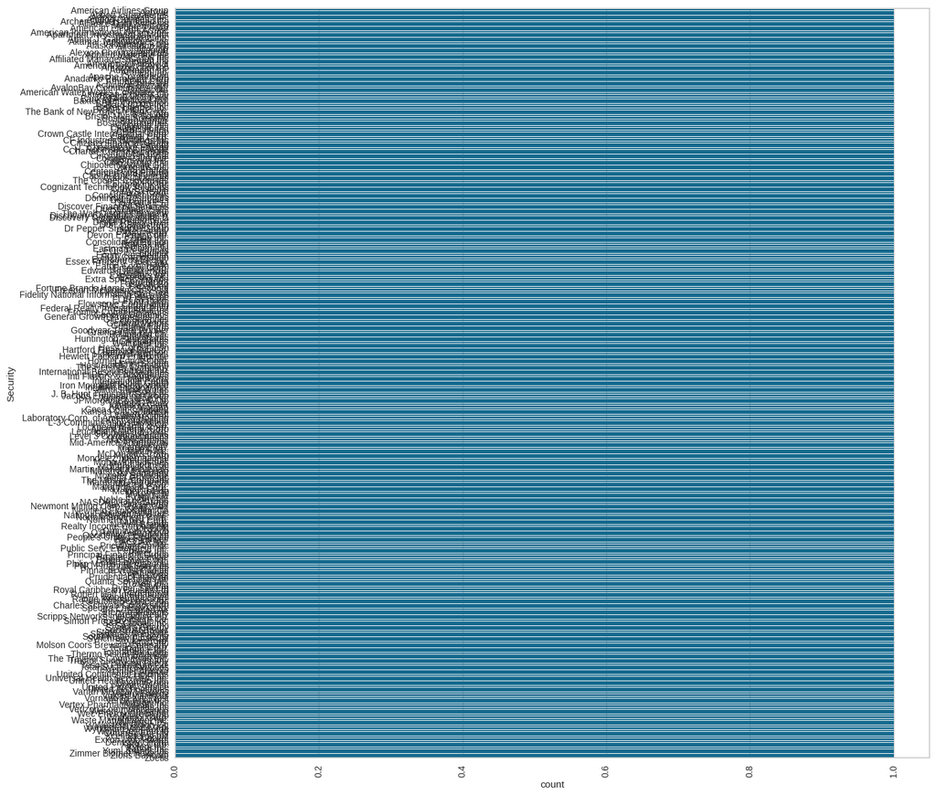

```
-------------------------------------------------------------------


GICS Sector

-------------------------------------------------------------------
```

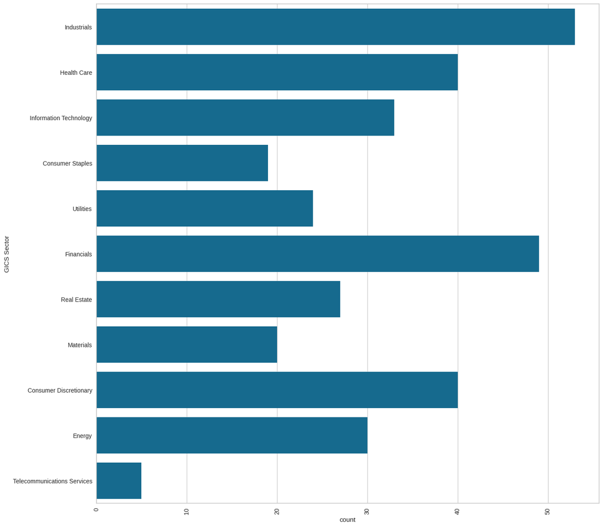

```
-------------------------------------------------------------------


GICS Sub Industry

-------------------------------------------------------------------
```

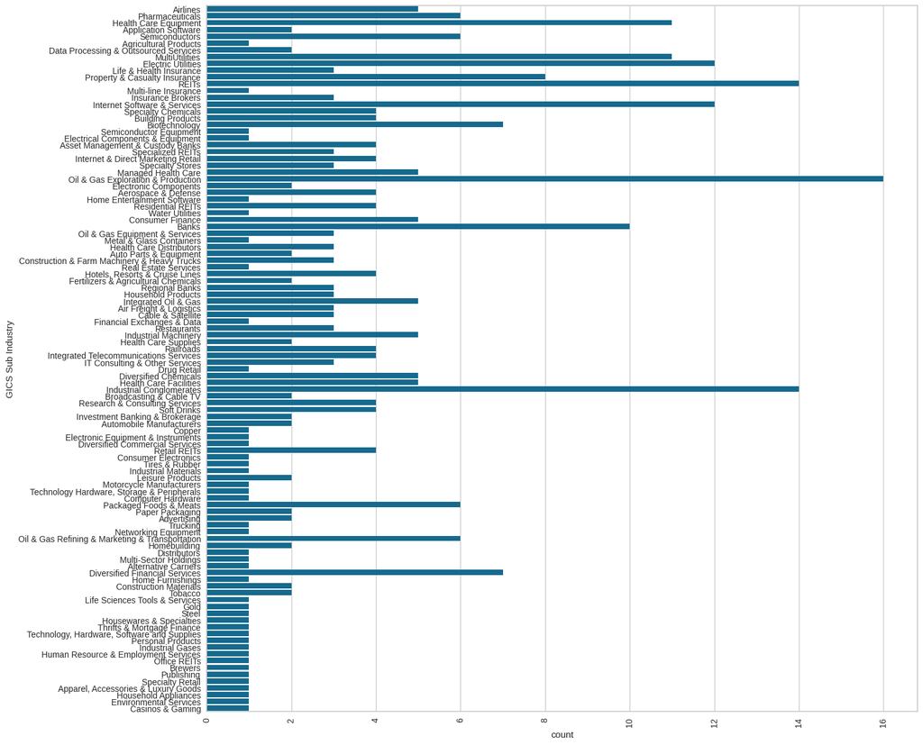

```
-------------------------------------------------------------------


Current Price

-------------------------------------------------------------------
```

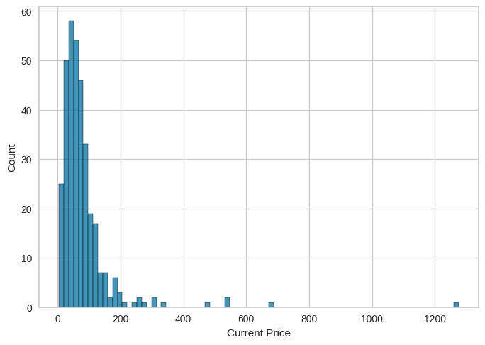

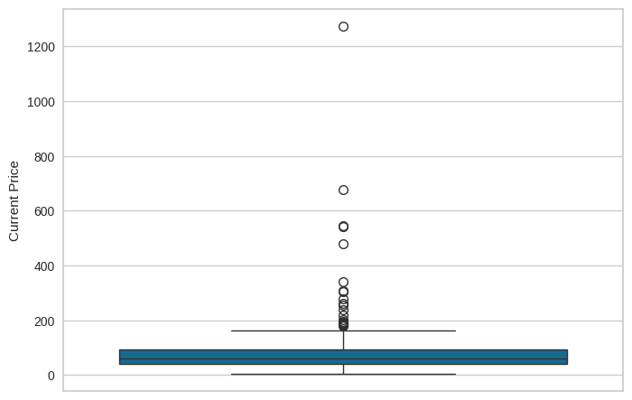

```
count     340.000000
mean       80.862345
std        98.055086
min         4.500000
25%        38.555000
50%        59.705000
75%        92.880001
max      1274.949951
Name: Current Price, dtype: float64

-------------------------------------------------------------------


Price Change

-------------------------------------------------------------------
```

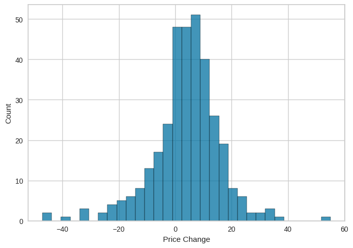

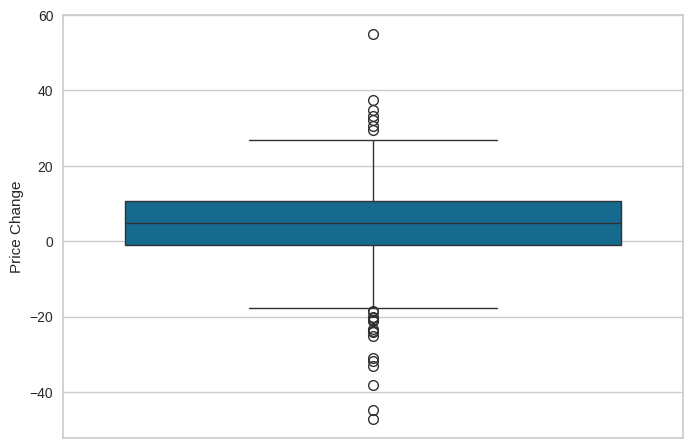

```
count    340.000000
mean       4.078194
std       12.006338
min      -47.129693
25%       -0.939484
50%        4.819505
75%       10.695493
max       55.051683
Name: Price Change, dtype: float64

-------------------------------------------------------------------


Volatility

-------------------------------------------------------------------
```

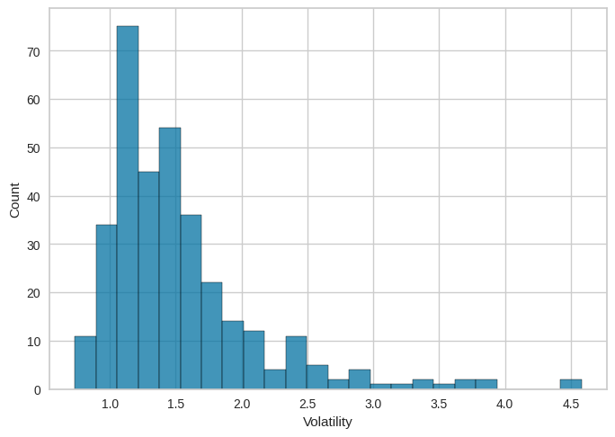

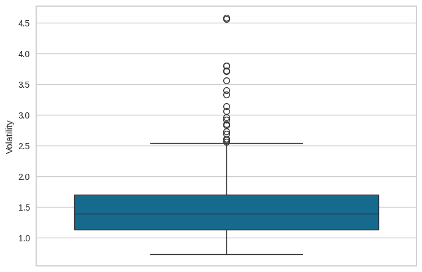

```
count    340.000000
mean       1.525976
std        0.591798
min        0.733163
25%        1.134878
50%        1.385593
75%        1.695549
max        4.580042
Name: Volatility, dtype: float64

-------------------------------------------------------------------


ROE

-------------------------------------------------------------------
```

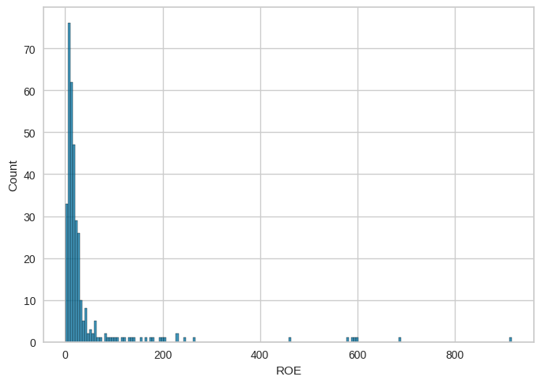

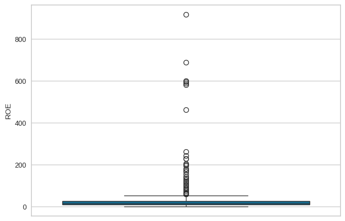

```
count    340.000000
mean      39.597059
std       96.547538
min        1.000000
25%        9.750000
50%       15.000000
75%       27.000000
max      917.000000
Name: ROE, dtype: float64

-------------------------------------------------------------------


Cash Ratio

-------------------------------------------------------------------
```

[14 more figures not shown]

```
count    340.000000
mean      -1.718249
std       13.966912
min      -76.119077
25%       -4.352056
50%       -1.067170
75%        3.917066
max      129.064585
Name: P/B Ratio, dtype: float64

-------------------------------------------------------------------
```

```python
univar(df)
```

Ticker Symbol - Based on graph, ticker symbol seems to have all unique values. This can most likely be dropped.

Security - Based on graph, security seems to have all unique values. This can most likely be dropped.

GICS Sector - Financials, Industrials, Health Care, and Consumer Discretionary are the largest sctors. Telecommunications Services th smallest.

GICS Sub Industry - Oil and gas exploration and discovery is the largest sub industry.

Current Price - Distribution is heavily skewed right with a max value over 1200 and the median being ~60. **This answers question 1 of the EDA questions.**

Price Change - Distribution is relatively normal with a median of 4.82 and minimum of -47.13 and max of 55.05.

Volatility - Distribution is right skewed. Median of 1.38 with minimum of 0.73 and max of 4.58.

ROE - Distribution heavily skewed right. Median of 15 with minimum of 1 and maximum of 917.

Cash Ratio - Distribution heavily skewed right. Median of 47 with minimum of 0 and maximum of 958.

Net Cash Flow - Distribution is normal shaped but with a right skew. Median value of 2.1x10^6, minimum of -1.12x10^10 and maximum of 2.076x10^10.

Net Income - Distribution relatively normal with median of 7.07x10^8 with a minimum of -2.35x10^10 and maximum of 2.44x10^10.

Earnings Per Share - Distribution left skewed with a median of 2.9 and minimum of -61.2 and maximum of 50.09.

P/E Ratio - Distribution heavily right skewed with median of 20.82 and minimum of 2.93 and maximum of 528.04.

P/B Ratio - Distribution relatively normal with a slight right skew. Median of -1.07 with a minimum of -76.12 and maximum of 129.06.

### **Bivariate Analysis**

```python
#Function to plot object variables with number variables
def bivar(datfr):
  print("Bivariate Analysis")
  cols = datfr.columns[2:]

  for col1 in cols:
    for col2 in cols:

      if col1 != col2:
        if datfr.dtypes[col1] == 'object' and (datfr.dtypes[col2] == 'float64' or datfr.dtypes[col2] == 'int64'):
          print(f"\n{col1} vs. {col2}")
          print('\n-------------------------------------------------------------------\n')
          fig, ax = plt.subplots(figsize=(25, 15))
          sns.boxplot(x=datfr[col1], y=datfr[col2], ax=ax, palette='cubehelix', hue=datfr[col1], legend=False)
          plt.xticks(rotation=90)
          plt.show()
          print('\n-------------------------------------------------------------------\n')
```

```
Bivariate Analysis

GICS Sector vs. Current Price

-------------------------------------------------------------------
```

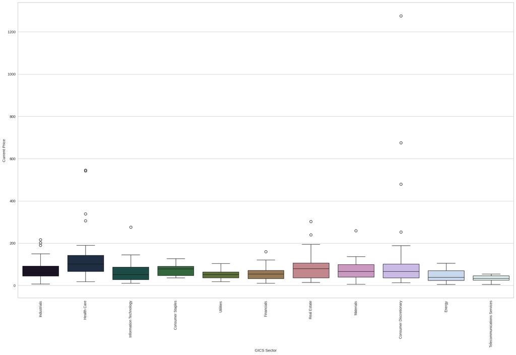

```
-------------------------------------------------------------------


GICS Sector vs. Price Change

-------------------------------------------------------------------
```

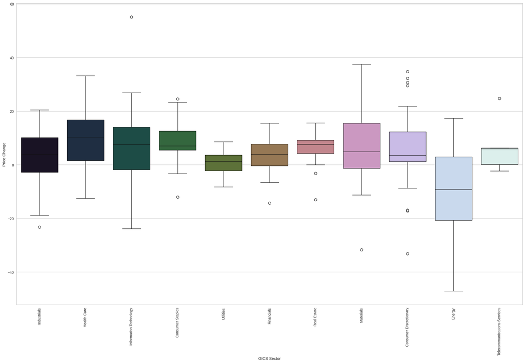

```
-------------------------------------------------------------------


GICS Sector vs. Volatility

-------------------------------------------------------------------
```

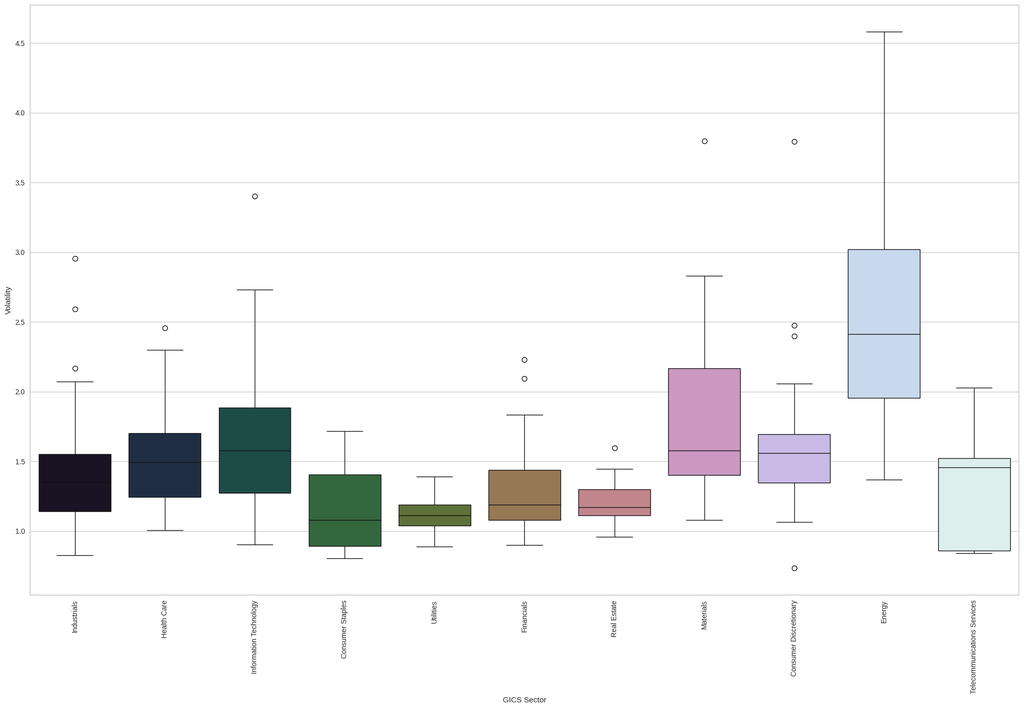

```
-------------------------------------------------------------------


GICS Sector vs. ROE

-------------------------------------------------------------------
```

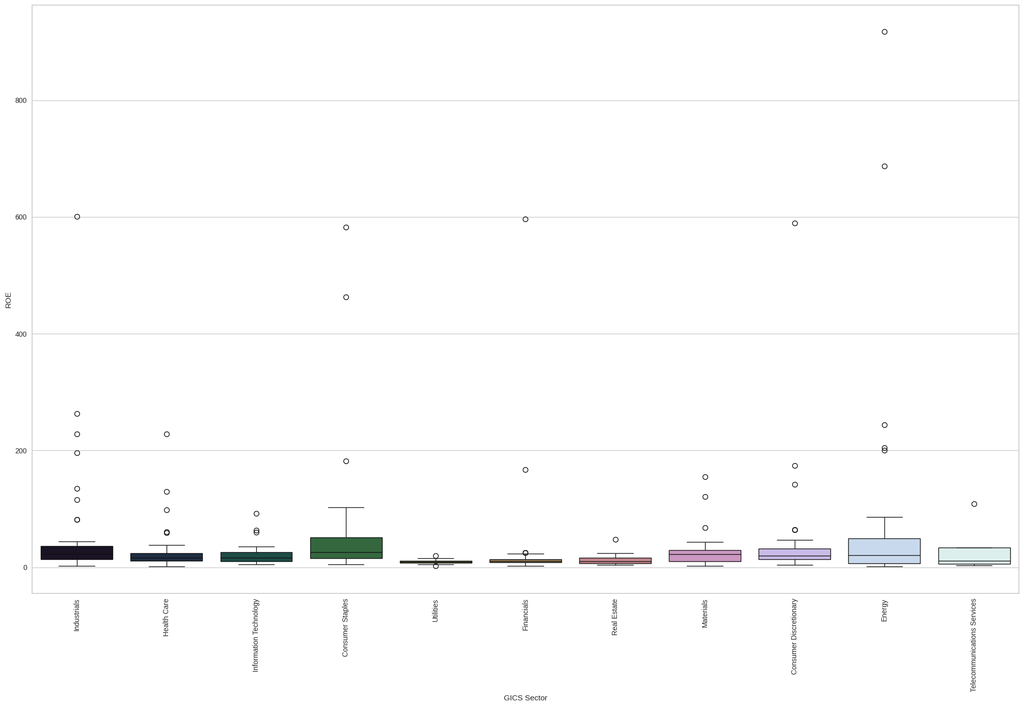

```
-------------------------------------------------------------------


GICS Sector vs. Cash Ratio

-------------------------------------------------------------------
```

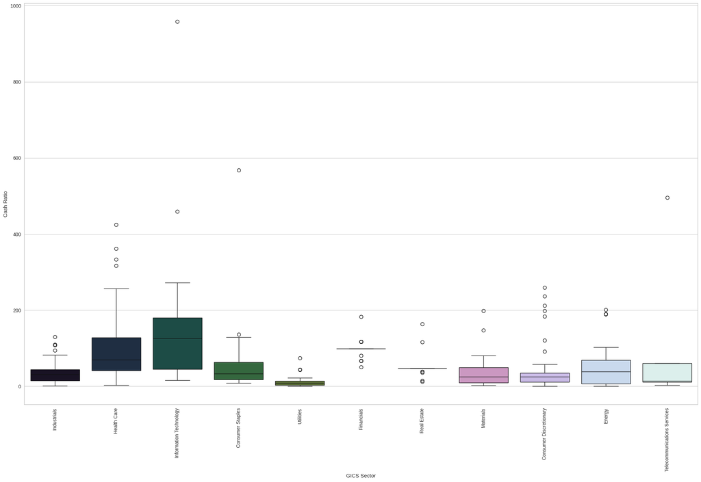

```
-------------------------------------------------------------------


GICS Sector vs. Net Cash Flow

-------------------------------------------------------------------
```

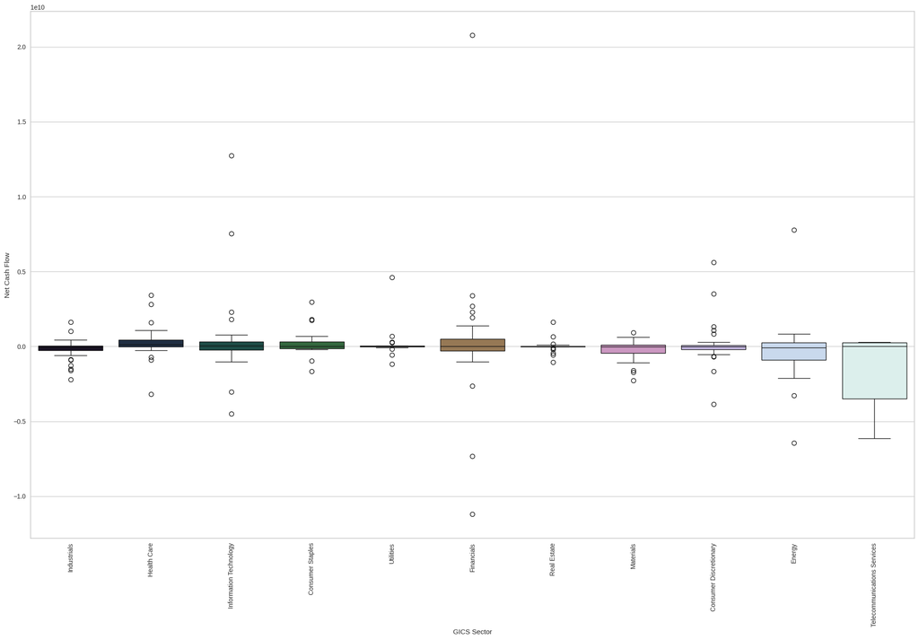

```
-------------------------------------------------------------------


GICS Sector vs. Net Income

-------------------------------------------------------------------
```

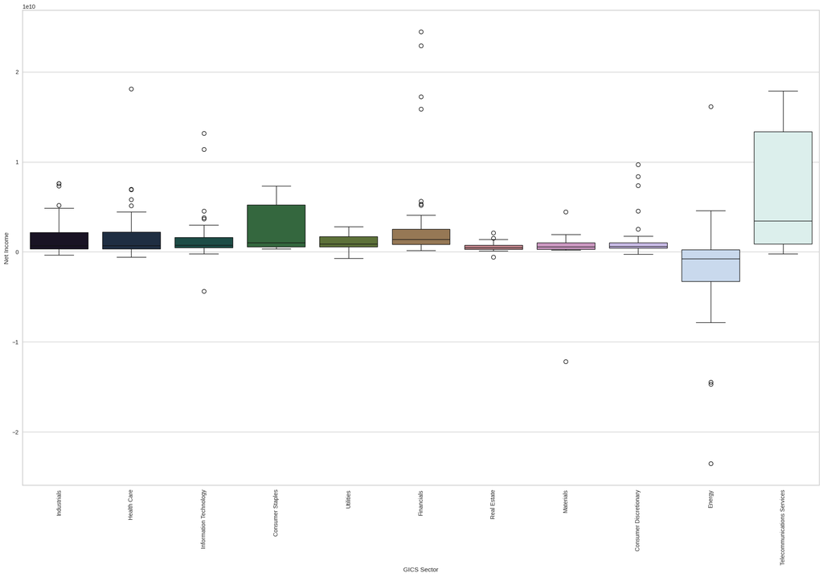

```
-------------------------------------------------------------------


GICS Sector vs. Earnings Per Share

-------------------------------------------------------------------
```

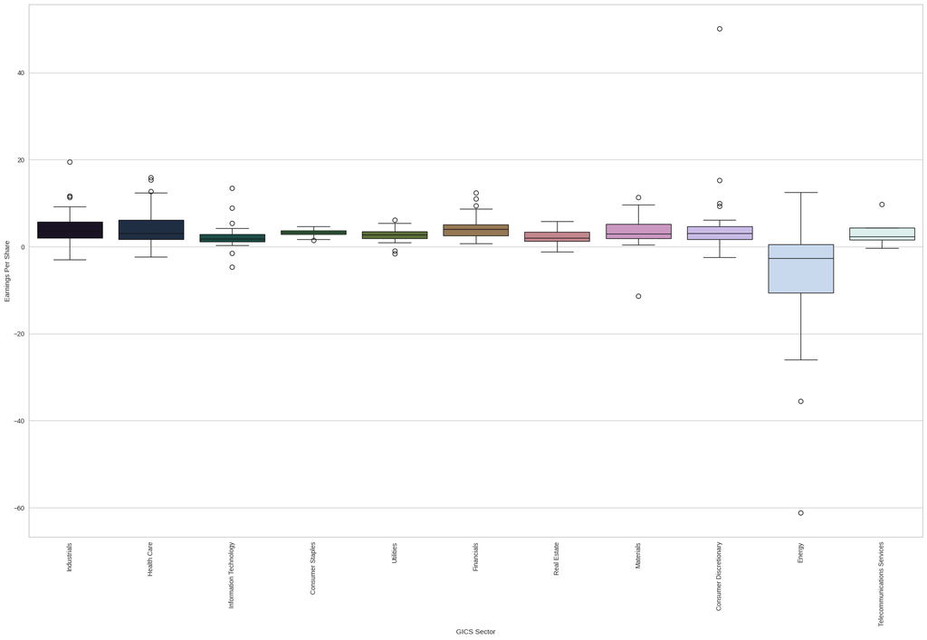

```
-------------------------------------------------------------------


GICS Sector vs. Estimated Shares Outstanding

-------------------------------------------------------------------
```

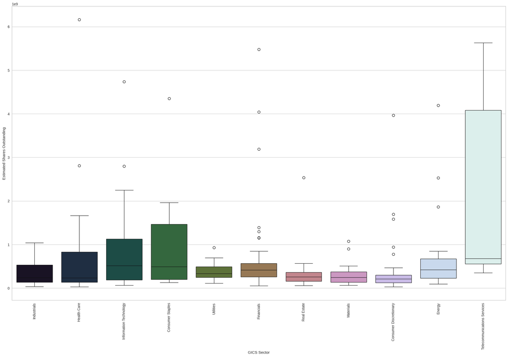

```
-------------------------------------------------------------------


GICS Sector vs. P/E Ratio

-------------------------------------------------------------------
```

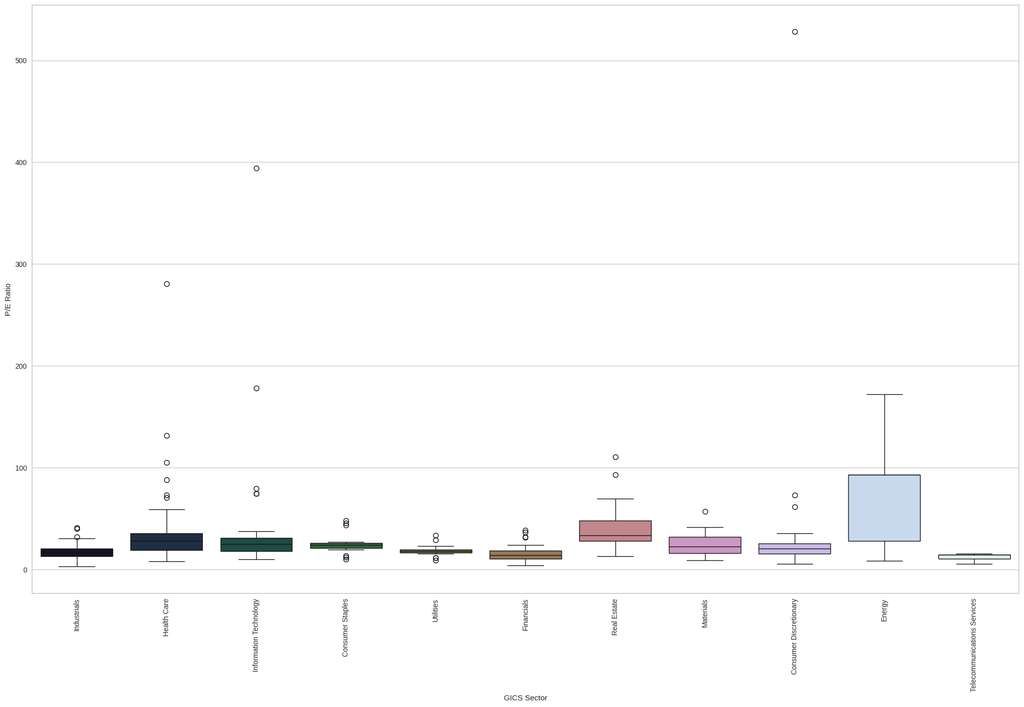

```
-------------------------------------------------------------------


GICS Sector vs. P/B Ratio

-------------------------------------------------------------------
```

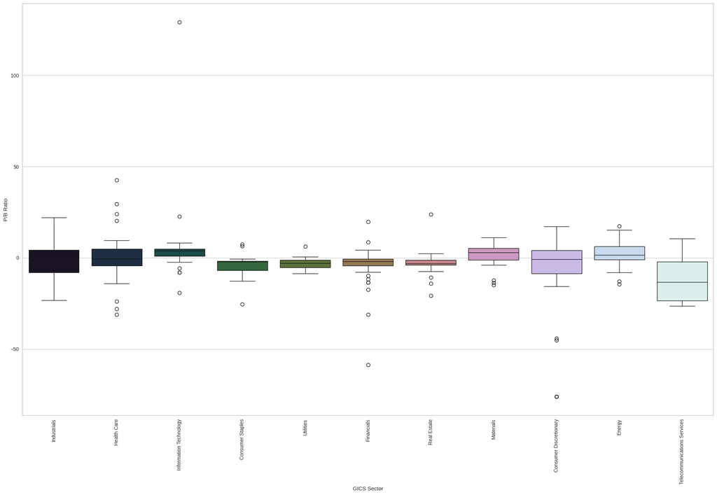

```
-------------------------------------------------------------------


GICS Sub Industry vs. Current Price

-------------------------------------------------------------------
```

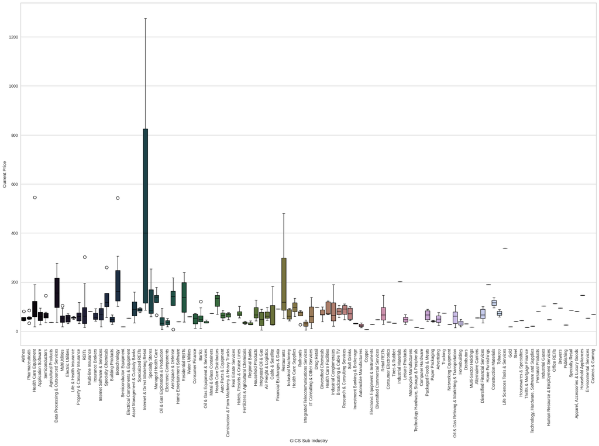

```
-------------------------------------------------------------------


GICS Sub Industry vs. Price Change

-------------------------------------------------------------------
```

[10 more figures not shown]

```python
bivar(df)
```

Question 4: Cash ratio provides a measure of a company's ability to cover its short-term obligations using only cash and cash equivalents. How does the average cash ratio vary across economic sectors?

The lowest median ratio goes to the utilities sector with a median around 10.

Question 5: P/E ratios can help determine the relative value of a company's shares as they signify the amount of money an investor is willing to invest in a single share of a company per dollar of its earnings. How does the P/E ratio vary, on average, across economic sectors?

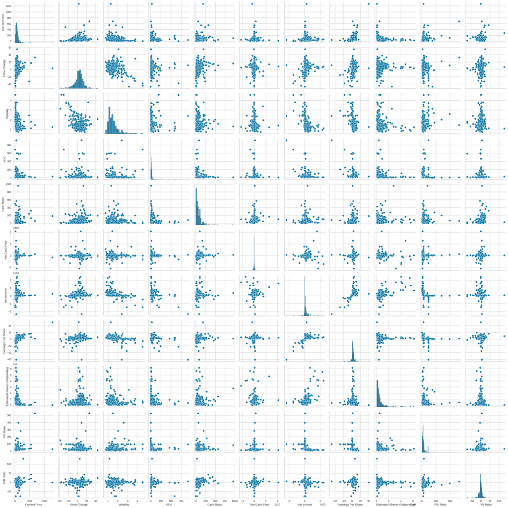

```python
#Check scatter plots of all numeric variables
sns.pairplot(df)
```

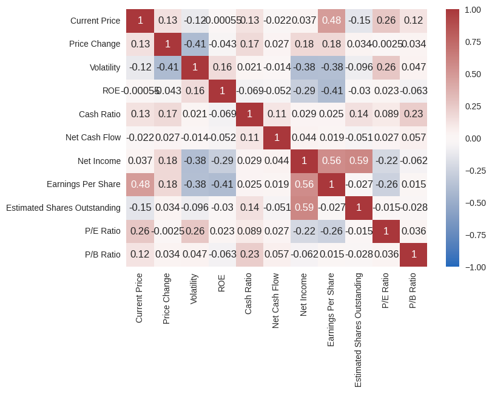

```python
#Check heatmap of all numeric variables
sns.heatmap(df.select_dtypes(include=np.number).corr(), annot=True, vmin=-1, vmax=1, cmap='vlag')
```

Question 3: How are the different variables correlated with each other?

Most of the variables are not highly correlated. The largest correlations occur between Estimated Shares Outstanding and Net Income, Earnings per Share and Net Income, Earnings per Share and current price, Volatility and Price Change, Earnings per Share and ROE, Net Income and Valitility, Earnings Per Share and Volatility.

## Data Preprocessing

- Duplicate value check
- Missing value treatment
- Outlier check
- Feature engineering (if needed)
- Any other preprocessing steps (if needed)

```python
#Make copy of original dataset
df_copy = df.copy()
```

```python
#Drop non-numeric variables
df_copy.drop(['Ticker Symbol', 'Security', 'GICS Sector', 'GICS Sub Industry'], axis=1, inplace=True)
```

```python
df_copy.head()
```

|  | Current Price | Price Change | Volatility | ROE | Cash Ratio | Net Cash Flow | Net Income | Earnings Per Share | Estimated Shares Outstanding | P/E Ratio | P/B Ratio |
| --- | --- | --- | --- | --- | --- | --- | --- | --- | --- | --- | --- |
| 0 | 42.349998 | 9.999995 | 1.687151 | 135 | 51 | -604000000 | 7610000000 | 11.39 | 6.681299e+08 | 3.718174 | -8.784219 |
| 1 | 59.240002 | 8.339433 | 2.197887 | 130 | 77 | 51000000 | 5144000000 | 3.15 | 1.633016e+09 | 18.806350 | -8.750068 |
| 2 | 44.910000 | 11.301121 | 1.273646 | 21 | 67 | 938000000 | 4423000000 | 2.94 | 1.504422e+09 | 15.275510 | -0.394171 |
| 3 | 93.940002 | 13.977195 | 1.357679 | 9 | 180 | -240840000 | 629551000 | 1.26 | 4.996437e+08 | 74.555557 | 4.199651 |
| 4 | 55.320000 | -1.827858 | 1.701169 | 14 | 272 | 315120000 | 696878000 | 0.31 | 2.247994e+09 | 178.451613 | 1.059810 |

```python
#Scale data to normalize values
df_Scaled=df_copy.apply(zscore)
```

```python
#Check first 5 rows after slaing data
df_Scaled.head()
```

|  | Current Price | Price Change | Volatility | ROE | Cash Ratio | Net Cash Flow | Net Income | Earnings Per Share | Estimated Shares Outstanding | P/E Ratio | P/B Ratio |
| --- | --- | --- | --- | --- | --- | --- | --- | --- | --- | --- | --- |
| 0 | -0.393341 | 0.493950 | 0.272749 | 0.989601 | -0.210698 | -0.339355 | 1.554415 | 1.309399 | 0.107863 | -0.652487 | -0.506653 |
| 1 | -0.220837 | 0.355439 | 1.137045 | 0.937737 | 0.077269 | -0.002335 | 0.927628 | 0.056755 | 1.250274 | -0.311769 | -0.504205 |
| 2 | -0.367195 | 0.602479 | -0.427007 | -0.192905 | -0.033488 | 0.454058 | 0.744371 | 0.024831 | 1.098021 | -0.391502 | 0.094941 |
| 3 | 0.133567 | 0.825696 | -0.284802 | -0.317379 | 1.218059 | -0.152497 | -0.219816 | -0.230563 | -0.091622 | 0.947148 | 0.424333 |
| 4 | -0.260874 | -0.492636 | 0.296470 | -0.265515 | 2.237018 | 0.133564 | -0.202703 | -0.374982 | 1.978399 | 3.293307 | 0.199196 |

## EDA

- It is a good idea to explore the data once again after manipulating it.

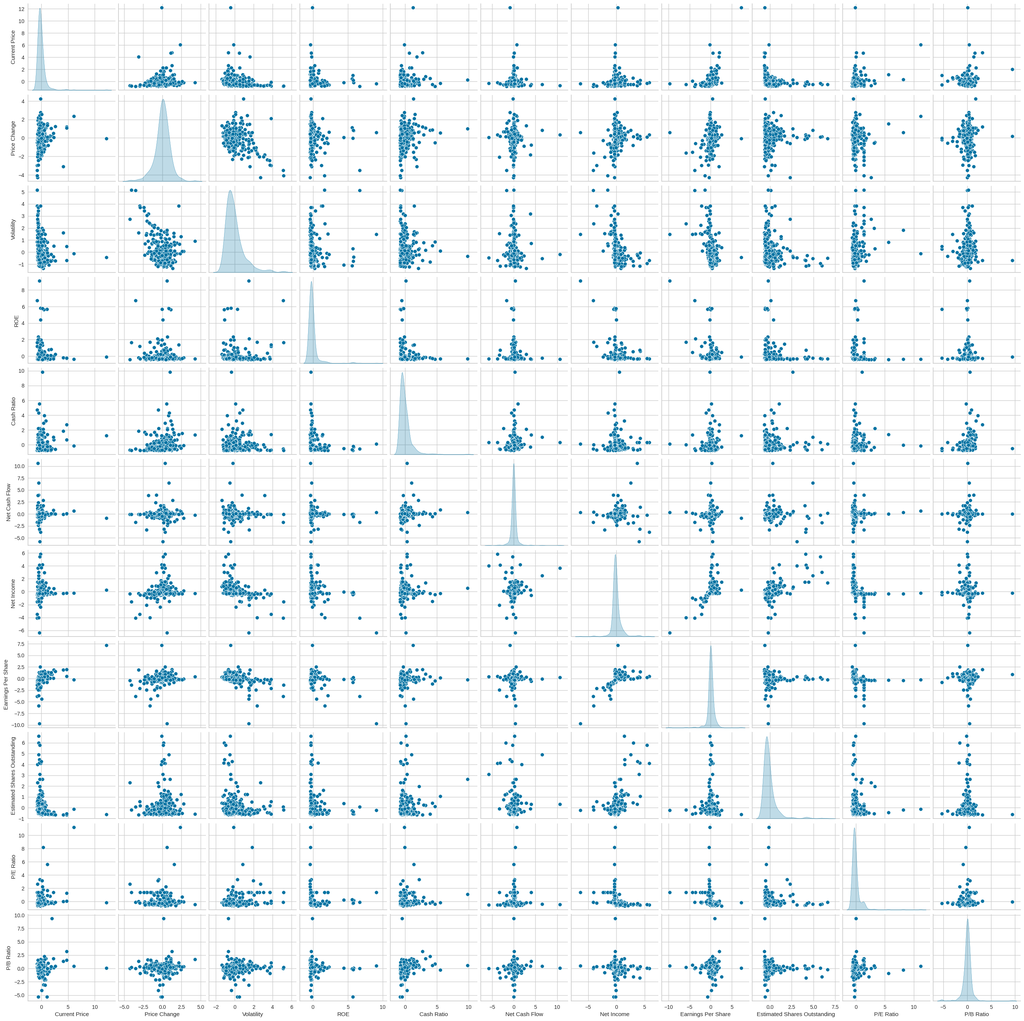

```python
#Check pair plot of all numeric variables after scaling
sns.pairplot(df_Scaled,diag_kind='kde')
```

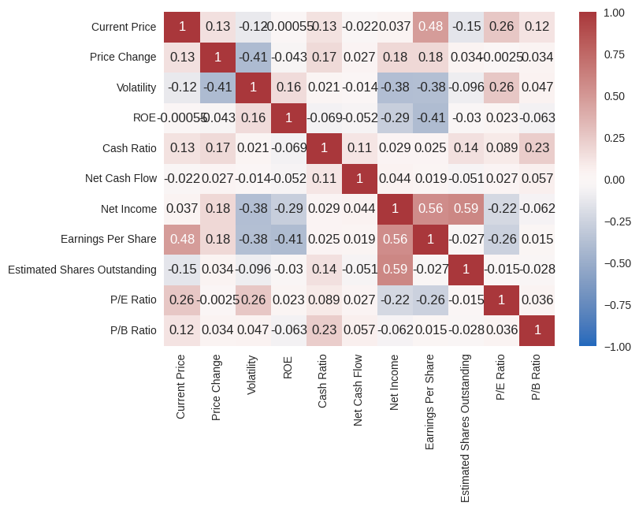

```python
#Check heatmap after scaling numeric variables
sns.heatmap(df_Scaled.corr(), annot=True, vmin=-1, vmax=1, cmap='vlag')
```

Same correlations between all variables remains with similar values before and after scaling of the data.